# Lineal Models and Statistical Learning

### Section A: Does IQ depend of the physical measures?

Load the `iqphys.csv` and make a multiple lineal regression. This data contains:

- Response (y): Performance IQ scores (PIQ) from the revised Wechsler Adult Intelligence Scale. This variable served as the investigator’s measure of the individual’s intelligence.
- Potential predictor (x1): Brain size based on the count obtained from MRI scans (given as count/10,000).
- Potential predictor (x2): Height in inches.
- Potential predictor (x3): Weight in pounds.

```r
data <- read.csv("data/iqphys.csv")
head(data)
```

|  | PIQ | Brain | Height | Weight |
| --- | --- | --- | --- | --- |
| 1 | 124 | 81.69 | 64.5 | 118 |
| 2 | 150 | 103.84 | 73.3 | 143 |
| 3 | 128 | 96.54 | 68.8 | 172 |
| 4 | 134 | 95.15 | 65.0 | 147 |
| 5 | 110 | 92.88 | 69.0 | 146 |
| 6 | 131 | 99.13 | 64.5 | 138 |

##### **- What predictor explain something about the IQ variability?**

We are going to make a pairs plot for seeing how are the predictors with the IQ.

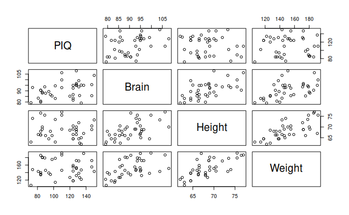

```r
pairs(data)
```

Like we can observe, only the `Brain` predictor has a correlation with `PIQ`. We are going to train a lineal model for seeing this result.

```r
model <- lm(PIQ ~ ., data = data)
summary(model)
```

```
Call:
lm(formula = PIQ ~ ., data = data)

Residuals:
   Min     1Q Median     3Q    Max
-32.74 -12.09  -3.84  14.17  51.69

Coefficients:
              Estimate Std. Error t value Pr(>|t|)
(Intercept)  1.114e+02  6.297e+01   1.768 0.085979 .
Brain        2.060e+00  5.634e-01   3.657 0.000856 ***
Height      -2.732e+00  1.229e+00  -2.222 0.033034 *
Weight       5.599e-04  1.971e-01   0.003 0.997750
---
Signif. codes:  0 ‘***’ 0.001 ‘**’ 0.01 ‘*’ 0.05 ‘.’ 0.1 ‘ ’ 1

Residual standard error: 19.79 on 34 degrees of freedom
Multiple R-squared:  0.2949,    Adjusted R-squared:  0.2327
F-statistic: 4.741 on 3 and 34 DF,  p-value: 0.007215
```

This result gives us the reason, only the `Brain` is the significant predictor, althought the `Height` too (in lower measure). In addition, the model has a poor $R^2$ that means that `PIQ` is not good explained by the predictors. Due to this result, our model will be without `Weight` predictor:

```r
model <- lm(PIQ ~ Brain + Height, data = data)
summary(model)
```

```
Call:
lm(formula = PIQ ~ Brain + Height, data = data)

Residuals:
    Min      1Q  Median      3Q     Max
-32.750 -12.090  -3.841  14.174  51.690

Coefficients:
            Estimate Std. Error t value Pr(>|t|)
(Intercept) 111.2757    55.8673   1.992 0.054243 .
Brain         2.0606     0.5466   3.770 0.000604 ***
Height       -2.7299     0.9932  -2.749 0.009399 **
---
Signif. codes:  0 ‘***’ 0.001 ‘**’ 0.01 ‘*’ 0.05 ‘.’ 0.1 ‘ ’ 1

Residual standard error: 19.51 on 35 degrees of freedom
Multiple R-squared:  0.2949,    Adjusted R-squared:  0.2546
F-statistic: 7.321 on 2 and 35 DF,  p-value: 0.002208
```

##### **- Provide a confidence interval for the coefficients.**

The confidence interval for the coefficients of model is:

```r
confint(model)
```

```
                 2.5 %      97.5 %
(Intercept) -2.1410228 224.6923622
Brain        0.9509088   3.1703892
Height      -4.7462046  -0.7136513
```

##### - What is the confidence interval of IQ for the values of the predictors: 95, 70 and 180?

As we have removed the `Weight` predictor, we will only use the data: `Brain = 95` and `Height = 70`:

```r
newdata <- data.frame(Brain = 95, Height = 70)
predict(model, newdata, interval = "prediction")
```

```
       fit     lwr      upr
1 115.9424 75.6293 156.2554
```

The size of the confidence interval is very big, this is due to there are few data and the model is bad.

##### **- Do the residuals follow a normal distribution? Make the convenients representations of the histogram and Q-Q chart.**

We are going to make the convenients representations for knowing if the residuals follow a normal distribution:

```r
par(mfrow=c(1,2))
hist(model$residuals)
qqnorm(model$residuals)
```

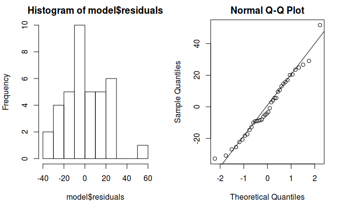

```r
qqline(model$residuals)
```

Also, we can plot the model with:

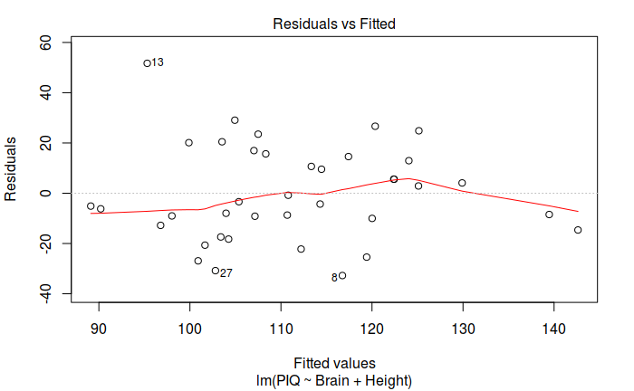

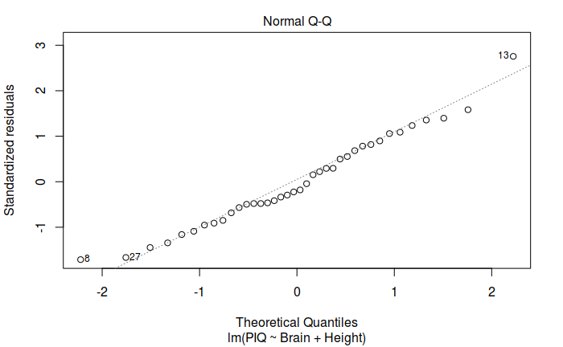

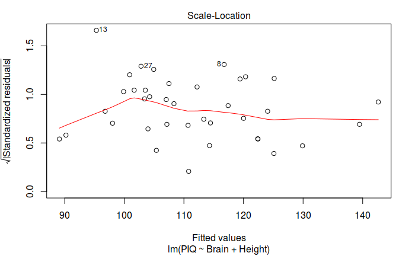

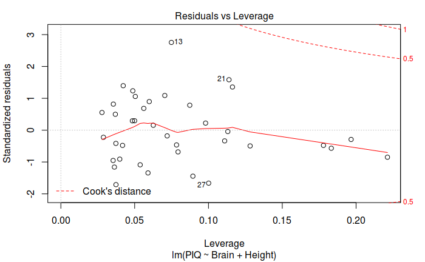

```r
plot(model)
```

Let’s test if the residuals follow a normal distribution with the Shapiro test:

```r
shapiro.test(model$residuals)
```

```
    Shapiro-Wilk normality test

data:  model$residuals
W = 0.976, p-value = 0.5764
```

As the `p-value > 0.05`, the residuals follow a normal distribution.

To end, let’s test with ANOVA if the reduced model is better than the original model:

```r
anova(lm(PIQ~., data=data), model)
```

```
Analysis of Variance Table

Model 1: PIQ ~ Brain + Height + Weight
Model 2: PIQ ~ Brain + Height
  Res.Df   RSS Df  Sum of Sq  F Pr(>F)
1     34 13322
2     35 13322 -1 -0.0031633  0 0.9977
```

As `p-value` is huge, the reduced model is better than original model.

### Section B

Load the `prostate` dataset of the library `ElemStatLearn` and remove the `train` column.

```r
# install.packages("ElemStatLearn")
library("ElemStatLearn")
data(prostate)
head(prostate)
```

|  | lcavol | lweight | age | lbph | svi | lcp | gleason | pgg45 | lpsa | train |
| --- | --- | --- | --- | --- | --- | --- | --- | --- | --- | --- |
| 1 | -0.5798185 | 2.769459 | 50 | -1.386294 | 0 | -1.386294 | 6 | 0 | -0.4307829 | TRUE |
| 2 | -0.9942523 | 3.319626 | 58 | -1.386294 | 0 | -1.386294 | 6 | 0 | -0.1625189 | TRUE |
| 3 | -0.5108256 | 2.691243 | 74 | -1.386294 | 0 | -1.386294 | 7 | 20 | -0.1625189 | TRUE |
| 4 | -1.2039728 | 3.282789 | 58 | -1.386294 | 0 | -1.386294 | 6 | 0 | -0.1625189 | TRUE |
| 5 | 0.7514161 | 3.432373 | 62 | -1.386294 | 0 | -1.386294 | 6 | 0 | 0.3715636 | TRUE |
| 6 | -1.0498221 | 3.228826 | 50 | -1.386294 | 0 | -1.386294 | 6 | 0 | 0.7654678 | TRUE |

```r
prostate$train <- NULL
head(prostate)
```

|  | lcavol | lweight | age | lbph | svi | lcp | gleason | pgg45 | lpsa |
| --- | --- | --- | --- | --- | --- | --- | --- | --- | --- |
| 1 | -0.5798185 | 2.769459 | 50 | -1.386294 | 0 | -1.386294 | 6 | 0 | -0.4307829 |
| 2 | -0.9942523 | 3.319626 | 58 | -1.386294 | 0 | -1.386294 | 6 | 0 | -0.1625189 |
| 3 | -0.5108256 | 2.691243 | 74 | -1.386294 | 0 | -1.386294 | 7 | 20 | -0.1625189 |
| 4 | -1.2039728 | 3.282789 | 58 | -1.386294 | 0 | -1.386294 | 6 | 0 | -0.1625189 |
| 5 | 0.7514161 | 3.432373 | 62 | -1.386294 | 0 | -1.386294 | 6 | 0 | 0.3715636 |
| 6 | -1.0498221 | 3.228826 | 50 | -1.386294 | 0 | -1.386294 | 6 | 0 | 0.7654678 |

##### **- What is the best model which explain the `lpsa` variable?**

Let’s make a `stepAIC` for know what is the best model:

```r
library(MASS)
fit0 <- lm(lpsa~1, data=prostate)
fit1 <- lm(lpsa~., data=prostate)
step <- stepAIC(fit0, direction = "forward", scope = list(lower = fit0, upper = fit1))
```

```
Start:  AIC=28.84
lpsa ~ 1

          Df Sum of Sq     RSS     AIC
+ lcavol   1    69.003  58.915 -44.366
+ svi      1    41.011  86.907  -6.658
+ lcp      1    38.528  89.389  -3.926
+ lweight  1    24.019 103.899  10.665
+ pgg45    1    22.814 105.103  11.783
+ gleason  1    17.416 110.502  16.641
+ lbph     1     4.136 123.782  27.650
+ age      1     3.679 124.239  28.007
<none>                 127.918  28.838

Step:  AIC=-44.37
lpsa ~ lcavol

          Df Sum of Sq    RSS     AIC
+ lweight  1    7.1726 51.742 -54.958
+ svi      1    5.2375 53.677 -51.397
+ lbph     1    3.2658 55.649 -47.898
+ pgg45    1    1.6980 57.217 -45.203
<none>                 58.915 -44.366
+ lcp      1    0.6562 58.259 -43.452
+ gleason  1    0.4156 58.499 -43.053
+ age      1    0.0025 58.912 -42.370

Step:  AIC=-54.96
lpsa ~ lcavol + lweight

          Df Sum of Sq    RSS     AIC
+ svi      1    5.1737 46.568 -63.177
+ pgg45    1    1.8158 49.926 -56.424
<none>                 51.742 -54.958
+ lcp      1    0.8187 50.923 -54.506
+ gleason  1    0.7163 51.026 -54.311
+ age      1    0.6456 51.097 -54.176
+ lbph     1    0.4440 51.298 -53.794

Step:  AIC=-63.18
```

[output cut: 13 more lines]

```
          Df Sum of Sq    RSS     AIC
+ age      1   1.15879 44.437 -63.723
<none>                 45.595 -63.226
+ pgg45    1   0.33173 45.264 -61.934
+ gleason  1   0.20691 45.389 -61.667
+ lcp      1   0.10115 45.494 -61.441

Step:  AIC=-63.72
lpsa ~ lcavol + lweight + svi + lbph + age

          Df Sum of Sq    RSS     AIC
<none>                 44.437 -63.723
+ pgg45    1   0.66071 43.776 -63.176
+ gleason  1   0.47674 43.960 -62.769
+ lcp      1   0.13040 44.306 -62.008
```

The best model by `stepAIC` is:

```r
step$anova
```

```
Stepwise Model Path
Analysis of Deviance Table

Initial Model:
lpsa ~ 1

Final Model:
lpsa ~ lcavol + lweight + svi + lbph + age

       Step Df   Deviance Resid. Df Resid. Dev       AIC
1                                96  127.91766  28.83755
2  + lcavol  1 69.0028748        95   58.91478 -44.36603
3 + lweight  1  7.1726080        94   51.74218 -54.95846
4     + svi  1  5.1737396        93   46.56844 -63.17744
5    + lbph  1  0.9729643        92   45.59547 -63.22555
6     + age  1  1.1587904        91   44.43668 -63.72263
```

```r
step$call
```

```
lm(formula = lpsa ~ lcavol + lweight + svi + lbph + age, data = prostate)
```

Its AIC value is:

```r
best.model <- lm(formula = lpsa ~ lcavol + lweight + svi + lbph + age, data = prostate)
extractAIC(best.model, scale=0)
```

```
[1]   6.00000 -63.72263
```

##### **- Provide a confidence interval for the coefficients.**

Let’s make a summary, get the coefficients and its confidence interval:

```r
summary(best.model)
```

```
Call:
lm(formula = lpsa ~ lcavol + lweight + svi + lbph + age, data = prostate)

Residuals:
     Min       1Q   Median       3Q      Max
-1.86717 -0.37725  0.01257  0.40252  1.44544

Coefficients:
            Estimate Std. Error t value Pr(>|t|)
(Intercept)  0.49473    0.87652   0.564  0.57385
lcavol       0.54400    0.07463   7.289 1.11e-10 ***
lweight      0.58821    0.19790   2.972  0.00378 **
svi          0.71490    0.20653   3.461  0.00082 ***
lbph         0.10122    0.05759   1.758  0.08215 .
age         -0.01644    0.01068  -1.540  0.12692
---
Signif. codes:  0 ‘***’ 0.001 ‘**’ 0.01 ‘*’ 0.05 ‘.’ 0.1 ‘ ’ 1

Residual standard error: 0.6988 on 91 degrees of freedom
Multiple R-squared:  0.6526,    Adjusted R-squared:  0.6335
F-statistic: 34.19 on 5 and 91 DF,  p-value: < 2.2e-16
```

```r
best.model$coefficients
```

```
(Intercept)      lcavol     lweight         svi        lbph         age
 0.49472926  0.54399786  0.58821270  0.71490398  0.10122333 -0.01644485
```

```r
confint(best.model)
```

```
                  2.5 %      97.5 %
(Intercept) -1.24636790 2.235826421
lcavol       0.39574550 0.692250218
lweight      0.19511033 0.981315072
svi          0.30465376 1.125154193
lbph        -0.01316571 0.215612382
age         -0.03764989 0.004760199
```